# Housing Subsidy

Lu Yii Wong

November 9,2023

# 1: Introduction

The Department of Housing and Community Development (HCD) of Emil City runs a home repair tax credit program. HCD currently has a low conversion rate for this program, likely because eligible homeowners are reached out to at random. To address this issue, I have been tasked to create a model that will allow HCD to better identify potential candidates who will more likely enroll in the home repair tax program. HCD wants to run a more targeted campaign, which will lower costs, while potentially increasing efficiency of the current outreach system. Using the existing data collected by HCD, I will build a classifier that will help inform a cost and benefit analysis.

## 1.1: Set Up

```r
options(scipen=10000000)

library(tidyverse)
library(kableExtra)
library(caret)
library(knitr)
library(pscl)
library(plotROC)
library(pROC)
library(lubridate)
```

```r
palette5 <- c("#981FAC","#CB0F8B","#FF006A","#FE4C35","#FE9900")
palette4 <- c("#981FAC","#FF006A","#FE4C35","#FE9900")
palette2 <- c("#981FAC","#FF006A")


HousingSubsidy <- read.csv("/Users/luyiiwong/Documents/GitHub/ppa.assignment/HW5/housingSubsidy.csv")
```

# 2: Data Exploration

## 2.1: Data Cleaning

To make the data from HCD useful, I reformatted and aggregated relevant campaign data. The cleaning process was important as I wanted to ensure that information like day and month data could be utilized in the data exploration phase. Here are examples of reformatted variables:

- `pdays`: indicates if this homeowner has been contacted for this campaign
- `campaign`: indicates the number of times the homeowner has been contacted for this campaign
- `previous`: indicates the number of times the homeowner has been contacted for a previous campaign
- `y`: indicates if the homeowner enrolled in the program
- `education`: indicates education attainment of homeowner, with basic education comprising up to high school education

```r
HousingSubsidy <- HousingSubsidy %>%
  mutate(pdays = case_when(
      pdays == 999 ~ "not contacted",
      TRUE ~ "previously contacted"),
    campaign = case_when(
      campaign <= 5 ~ "0-5 times",
      campaign <= 10 ~ "6-10 times",
      TRUE ~ "11 times or more"),
    previous = case_when(
      previous == 0 ~ "never contacted",
      previous <= 3 ~ "contacted 1-3 times",
      TRUE ~ "contacted more than 3 times"),
    y = case_when(
      y == "yes" ~ "a.yes",
      y == "no" ~ "b.no"),
    education = case_when(
      education %in% c("basic.4y", "basic.6y", "basic.9y", "high.school") ~ "basic education",
      education %in% c("professional.course", "university.degree") ~ "higher education",
      TRUE ~ "other"))
```

```r
# month
HousingSubsidy <- HousingSubsidy %>%
  group_by(month) %>%
  summarise(enter = sum(y_numeric),
            n=n(),
            monthEnterAvg = round(100*(enter/n), 2))%>%
  dplyr::select(-enter, -n) %>%
  right_join(HousingSubsidy,.)

# day of week
HousingSubsidy <- HousingSubsidy %>%
  group_by(day_of_week) %>%
  summarise(enter = sum(y_numeric),
            n=n(),
            dayEnterAvg = round(100*(enter/n), 2))%>%
  dplyr::select(-enter, -n) %>%
  right_join(HousingSubsidy,.)

# education
HousingSubsidy <- HousingSubsidy %>%
  group_by(education) %>%
  summarise(enter = sum(y_numeric),
            n=n(),
            eduEnterAvg = round(100*(enter/n), 2))%>%
  dplyr::select(-enter, -n) %>%
  right_join(HousingSubsidy,.)

# job
HousingSubsidy <- HousingSubsidy %>%
  group_by(job) %>%
  summarise(enter = sum(y_numeric),
            n=n(),
            jobEnterAvg = round(100*(enter/n), 2))%>%
  dplyr::select(-enter, -n) %>%
  right_join(HousingSubsidy,.)
```

## 2.2: Data Visualization

Visualizing the data is helpful to identify patterns and correlation in the initial phase of the work. In this section, I have plotted various data points to understand characteristics of homeowners who enroll in the home repair tax credit program. The variables that I consider are separated into two categories: numerical and categorical variables.

### 2.2.1: Numeric Variables

Figure 2.1 is a bar plot showing the relationship between the likelihood of enrollment based on age, amount spent on home repairs, and unemployment rate. Figure 2.3 is a bar plot showing the likelihood of enrollment based on confidence index, price index and inflation rate. Figure 2.2 and Figure 2.4 displays the same data seen in Figures 2.1 and 2.3, respectively, in the format of a line graph.

Using these graphs, my preliminary findings using the data are:

- `age`: seems to have no relevance on enrollment
- `spent_on_repairs`: seems to have no relevance on enrollment
- `unemploy_rate`: lower employment rate leads to higher enrollment rates
- `cons.price.idx`: seems to have no relevance on enrollment
- `cons.con.idx`: seems to have no relevance on enrollment
- `inflation_rate`: lower inflation rate is related to higher enrollment

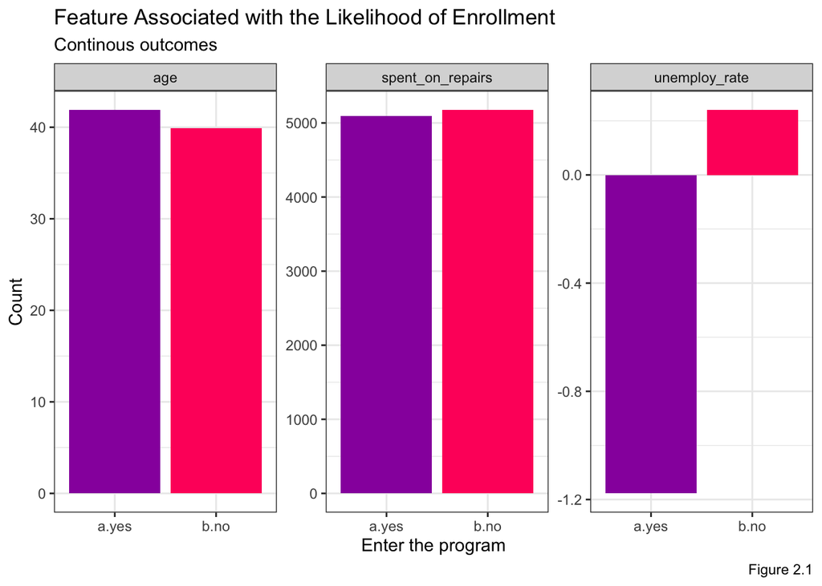

```r
HousingSubsidy %>%
  dplyr::select(y, age, unemploy_rate, spent_on_repairs) %>%
  gather(Variable, value, -y) %>%
    ggplot(aes(y, value, fill=y)) +
      geom_bar(position = "dodge", stat = "summary", fun = "mean") +
      facet_wrap(~Variable, scales = "free") +
      scale_fill_manual(values = palette2) +
      labs(x="Enter the program", y="Count",
           title = "Feature Associated with the Likelihood of Enrollment",
           subtitle = "Continous outcomes",
           caption = "Figure 2.1") +
      theme_bw() +
      theme(legend.position = "none")
```

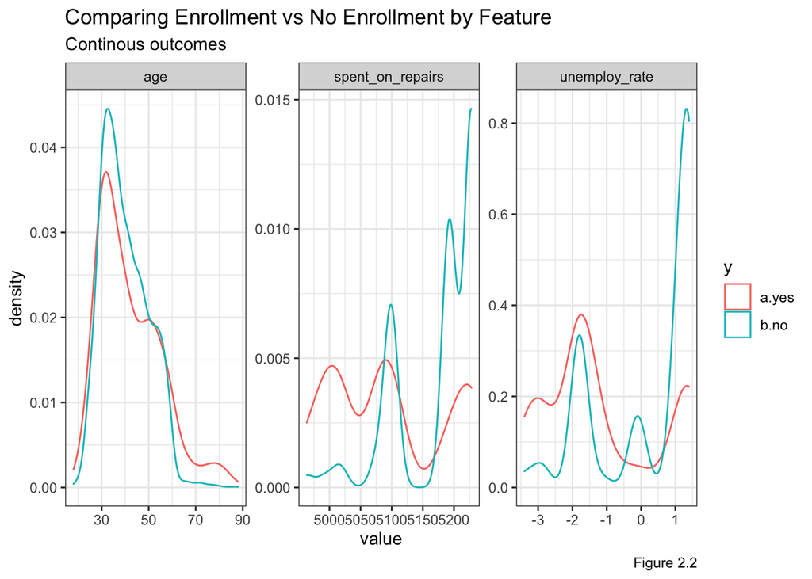

```r
HousingSubsidy %>%
    dplyr::select(y, age, unemploy_rate, spent_on_repairs) %>%
    gather(Variable, value, -y) %>%
    ggplot() +
    geom_density(aes(value, color=y), fill = "transparent") +
    facet_wrap(~Variable, scales = "free") +
    scale_fill_manual(values = palette2) +
    labs(title = "Comparing Enrollment vs No Enrollment by Feature",
         subtitle = "Continous outcomes",
         caption = "Figure 2.2")+
  theme_bw()
```

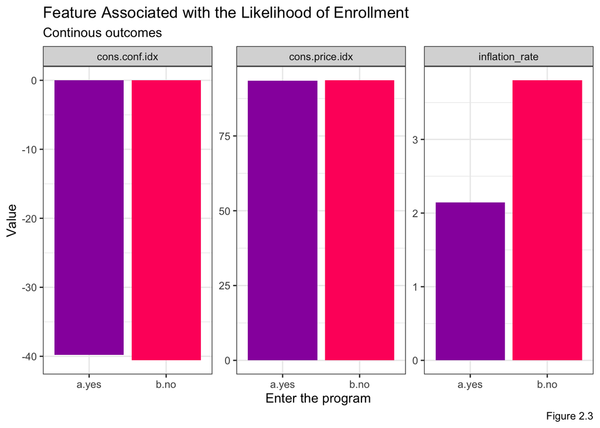

```r
HousingSubsidy %>%
  dplyr::select(y, cons.price.idx, cons.conf.idx, inflation_rate) %>%
  gather(Variable, value, -y) %>%
    ggplot(aes(y, value, fill=y)) +
      geom_bar(position = "dodge", stat = "summary", fun = "mean") +
      facet_wrap(~Variable, scales = "free") +
      scale_fill_manual(values = palette2) +
      labs(x="Enter the program", y="Value",
           title = "Feature Associated with the Likelihood of Enrollment",
           subtitle = "Continous outcomes",
           caption = "Figure 2.3") +
      theme_bw()+
      theme(legend.position = "none")
```

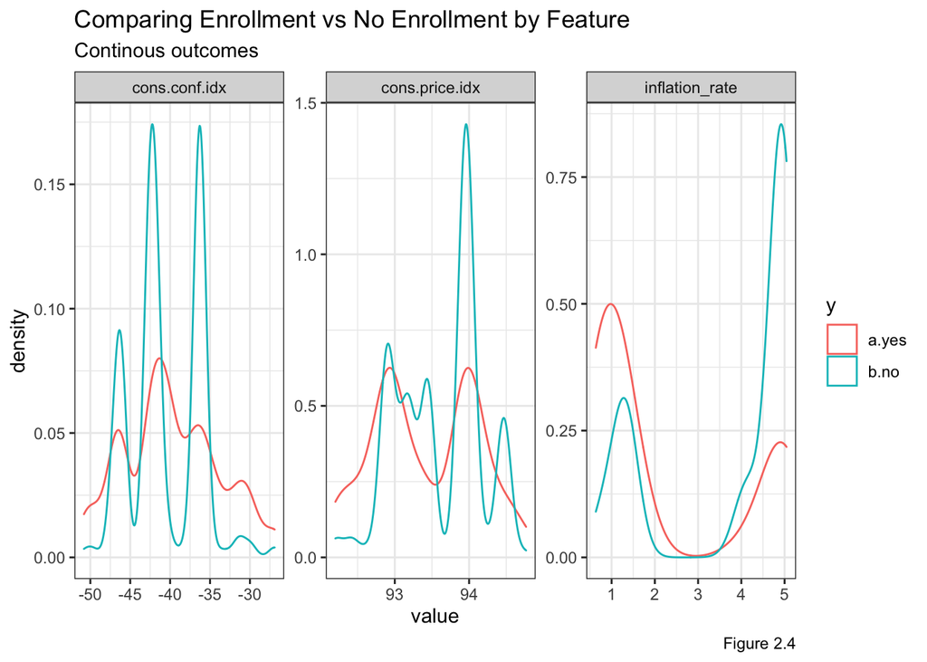

```r
HousingSubsidy %>%
    dplyr::select(y, cons.price.idx, cons.conf.idx, inflation_rate) %>%
    gather(Variable, value, -y) %>%
    ggplot() +
    geom_density(aes(value, color=y), fill = "transparent") +
    facet_wrap(~Variable, scales = "free") +
    scale_fill_manual(values = palette2) +
    labs(title = "Comparing Enrollment vs No Enrollment by Feature",
         subtitle = "Continous outcomes",
         caption = "Figure 2.4") +
    theme_bw()
```

### 2.2.2: Categorical Variables

Figure 2.5 in a bar plot displaying the relationship between selected categorical variables if a household enrolled in the home repair program. Here are some of the findings:

- `education`: homeowners with higher education attainment were more likely to enroll in the program than homeowners with basic education attainment
- `marital`: the highest number of enrollment group were married homeowners
- `taxbill_in_phl`: homeowners whose primary residence was in Philadelphia were more likely to enroll in the program than those who weren’t
- `taxLien`: homeowners without a tax lien against their property were most likely to enroll in the program

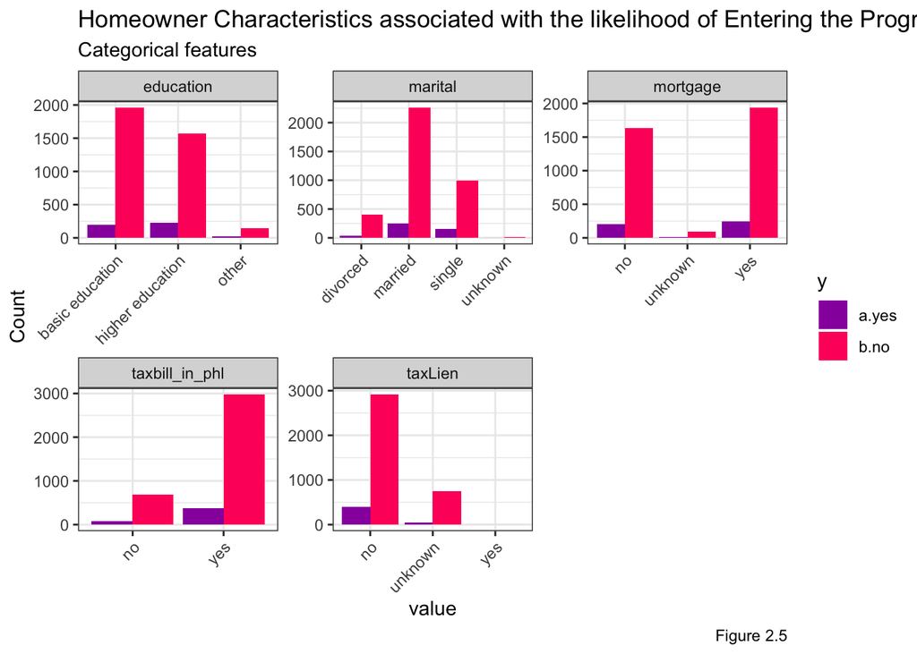

```r
HousingSubsidy %>%
  dplyr::select(y, taxLien, mortgage, taxbill_in_phl, marital, education) %>%
  gather(Variable, value, -y)  %>%
  count(Variable, value, y) %>%
    ggplot(., aes(value, n, fill = y)) +
        geom_bar(position = "dodge", stat="identity") +
        facet_wrap(~Variable, scales="free") +
        scale_fill_manual(values = palette2) +
        labs(y="Count",
             title = "Homeowner Characteristics associated with the likelihood of Entering the Program",
             subtitle = "Categorical features",
             caption = "Figure 2.5") +
        theme_bw()+
        theme(axis.text.x = element_text(angle = 45, hjust = 1))
```

- `contact`: homeowners contacted via cellular were much more likely to enroll than those contacted via telephone
- `day_of_week`: the day of the week which homeowners were contacted had little impact to their enrollment status
- `month`: HCD saw the highest number of enrollment in May, however, this could also be because it was the month with the highest volume of calls being made. Months like March and December with low call volumes also had higher number of enrollments than no enrollments.

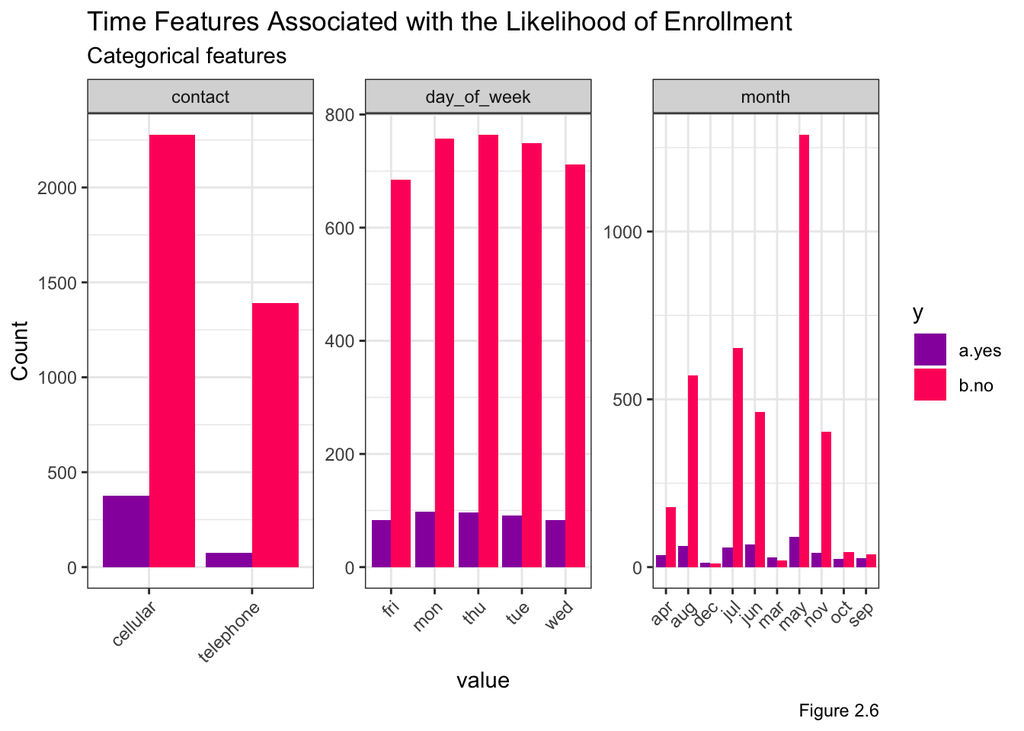

```r
HousingSubsidy %>%
  dplyr::select(y, contact, month, day_of_week) %>%
  gather(Variable, value, -y)  %>%
  count(Variable, value, y) %>%
    ggplot(., aes(value, n, fill = y)) +
        geom_bar(position = "dodge", stat="identity") +
        facet_wrap(~Variable, scales="free") +
        scale_fill_manual(values = palette2) +
        labs(y="Count",
             title = "Time Features Associated with the Likelihood of Enrollment",
             subtitle = "Categorical features",
             caption = "Figure 2.6") +
        theme_bw()+
        theme(axis.text.x = element_text(angle = 45, hjust = 1))
```

Figure 2.7 displays the relationship between previous contacts for other campaigns and current contact patterns for this campaign to the likelihood of enrollment. Overall, I found that:

- `campaign`: most homeowners were contacted 0-5 times for this campaign, but overall, enrollment rate were low across all categories
- `pdays`: most homeowners had not been contacted for a previous campaign. Homeowners who were contacted previously were more likely to enroll in this campaign than not. Homeowners who were not previously contacted were significantly more likely to not enroll in this program.
- `poutcome`: homeowners who had successful enrollment in a previous campaign were most likely to enroll in this campaign.
- `previous`: homeowners who had been contacted prior to this campaign had a higher rate of enrollment than those never contacted. Homeowners who had previously been contacted more than 3 times had the higher rate of enrollment for this campaign.

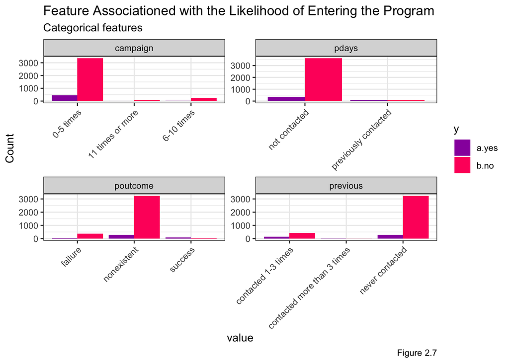

```r
HousingSubsidy %>%
  dplyr::select(y, campaign, pdays, previous, poutcome) %>%
  gather(Variable, value, -y)  %>%
  count(Variable, value, y) %>%
    ggplot(., aes(value, n, fill = y)) +
        geom_bar(position = "dodge", stat="identity") +
        facet_wrap(~Variable, scales="free") +
        scale_fill_manual(values = palette2) +
        labs(y="Count",
             title = "Feature Associationed with the Likelihood of Entering the Program",
             subtitle = "Categorical features",
             caption = "Figure 2.7") +
        theme_bw()+
        theme(axis.text.x = element_text(angle = 45, hjust = 1))
```

# 3: Logistic Regression Model

## 3.1: Creating Training Test Set

To train the model, I chose to split the data into a 65/35 training set. This means that 65 percent of the HCD data was used to train the model, and 35 percent of the data is used to test the model.

```r
set.seed(3456)
trainIndex <- createDataPartition(HousingSubsidy$y, p = .65,
                                  list = FALSE,
                                  times = 1)
housingSubsidyTrain <- HousingSubsidy[ trainIndex,]
housingSubsidyTest  <- HousingSubsidy[-trainIndex,]
```

## 3.2: First model

When deciding on features for the first regression model, I chose to take out two features that are marginally significant and the feature that indicates if the subsidy was taken. So, I chose to remove inflation rate, unemployment rate and tax lien.

This model showed that the features `contact` and `spent_on_repair` had a high significance.

```r
housingSubsidyModel <- glm(y_numeric ~ .,
                  data=housingSubsidyTrain %>%
                  dplyr::select(-X, -y, -inflation_rate, -unemploy_rate, -taxLien),
                  family="binomial" (link="logit"))

summary(housingSubsidyModel)
```

[output not shown]

## 3.3: Second Model

Considering the observations from the first model, I adjusted the features used in the second model. First I tried removing `spent_on_repair` and `contact` variables. I also tested other combinations of featured incorporated into the second model. Ultimately, the second model displayed here includes `taxLien` and excludes `inflation_rate`, `unemploy_rate`, and `contact` variables.

```r
housingSubsidyModel_2 <- glm(y_numeric ~ .,
                  data=housingSubsidyTrain %>%
                  dplyr::select(-X, -y, -inflation_rate, -unemploy_rate, -contact),
                  family="binomial" (link="logit"))

summary(housingSubsidyModel_2)
```

[output not shown]

# 4: Goodness of Fit

Unlike a linear model (lm), a generalized linear model (glm) uses the McFadden score, or the pseudo-r-squared value, to understand the fit of the model. Generally, a value closer to 1 indicates that the model is a better fit. While testing the models, I found that tweaking the model did not improve the McFadden score. Ultimately, the first model I tested, that had the least features removed, performed the best. The first model produced a McFadden score of 0.21. The best alternative model I tested produced a McFadden score of 0.209. Most other models tested produced scores ranging from 0.15 to 0.18.

```r
pR2(housingSubsidyModel)
pR2(housingSubsidyModel_2)
```

[output not shown]

## 4.1: Testing Predictions

I wanted to an alternative method to evaluate the performance of my model. To do this, I compared the outcome of the housing subsidy test set against the predicted probability of the housing subsidy model. These predictions are the estimated probabilities of enrolling in the home repair tax credit program. I then compare the predicted probabilities to the observed outcome.

```r
testProbs <- data.frame(Outcome = as.factor(housingSubsidyTest$y_numeric),
                        Probs = predict(housingSubsidyModel, housingSubsidyTest, type= "response"))
```

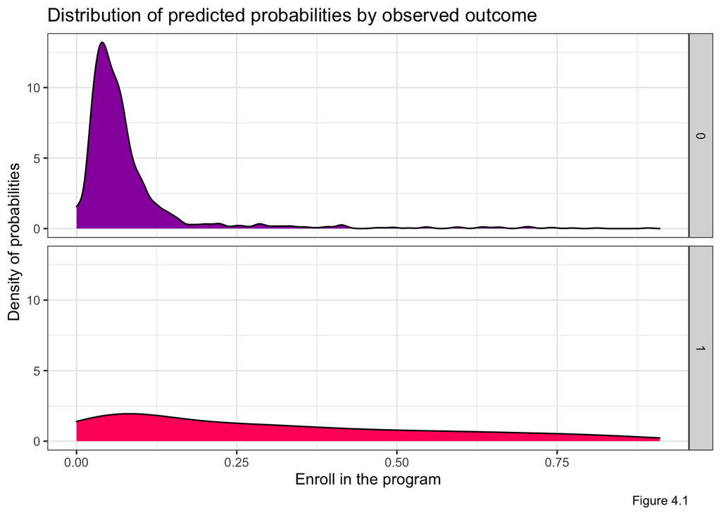

```r
ggplot(testProbs, aes(x = Probs, fill = as.factor(Outcome))) +
  geom_density() +
  facet_grid(Outcome ~ .) +
  scale_fill_manual(values = palette2) +
  labs(x = "Enroll in the program", y = "Density of probabilities",
       title = "Distribution of predicted probabilities by observed outcome",
       caption = "Figure 4.1") +
  theme_bw() +
  theme(strip.text.x = element_text(size = 18),
        legend.position = "none")
```

## 4.2: Confusion Matrix

A confusion matrix is a helpful tool that shows how many predictions are correct and incorrect in a model. The outcomes of the predictions are classified into four categories:

- **True Positive**: The model predicted **correctly** that the homeowner **would enroll** in the credit program
- **True Negative**: The model **correctly** predicted that the homeowner **would not enroll** in the credit program
- **False Positive**: The model **incorrectly** predicted that the homeowner **would enroll** in the program
- **False Negative**: The model **incorrectly** predicted that the homeowner **would not** enroll in the program, but they did

For this test, I set the predicted probability at a threshold greater than 0.5. This means that if a probability is greater than 0.5, it will be classified as “enrollment.” A probability less than or equal to 0.5 would be classified as “no enrollment”.

```r
testProbs <-
  testProbs %>%
  mutate(predOutcome  = as.factor(ifelse(testProbs$Probs > 0.5 , 1, 0)))
```

```r
caret::confusionMatrix(testProbs$predOutcome, testProbs$Outcome,
                       positive = "1")

# A "confusion matrix" for the threshold of 50% shows us the rate at which we got True Positives (aka Sensitivity), False Positives, True Negatives (aka Specificity) and False Negatives for that threshold.
```

[output not shown]

### 4.2.1: Confusion Matrix Discussion

The test showed that there were 37 **true positives**, instances where the model correctly predicted homeowner enrollment. There were 1261 **true negatives**, instances where the model correctly predicted that the homeowner would not enroll.

Overall, the model performed very well, with an accuracy over 90 percent. Other metrics that can help determine the performance of a model is sensitivity and specificity. The sensitivity of the model is derived from the true positives, while the specificity of the model is derived from the true negatives. This model had a sensitivity of 24 percent and a specificity of 98 percent.

This shows that the model had very high specificity. The model is very good a correctly identifying homeowners who would not enroll into the home repair tax credit program. The model has low sensitivity, as it struggles to correctly identify homeowners who will enroll in the program. Despite have high accuracy, over 90 percent, this model suggests that there is a large imbalance in the data set. The HCD data used to train the model had significantly more data on homeowners who did not enroll in the program than those who did. Hence, the model has high accuracy but low sensitivity due to the model’s limited ability to identify positive cases correctly.

## 4.3: ROC Curve

The area under the curve is 0.79. This indicates that the model is a good fit. The predicted outcome of the model is better than a coin flip. The current model also avoids being over fitted, making it generalizable.

```r
auc(testProbs$Outcome, testProbs$Probs)
```

[output not shown]

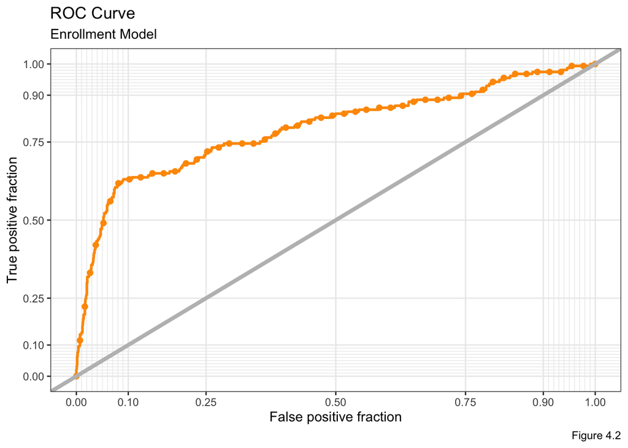

```r
ggplot(testProbs, aes(d = as.numeric(Outcome), m = Probs)) +
  geom_roc(n.cuts = 50, labels = FALSE, colour = "#FE9900") +
  style_roc(theme = theme_grey) +
  geom_abline(slope = 1, intercept = 0, size = 1.5, color = 'grey') +
  labs(title = "ROC Curve",
       subtitle = "Enrollment Model",
       caption = "Figure 4.2")+
  theme_bw()
```

# 5: Cross-Validation

Cross-Validation is an alternative method used to evaluate the performance of a model. Here, I used a 100 fold k-fold cross-validation. This helped me understand the ROC, sensitivity, and specificity of the model.

By running the cross-validation, I found the following:

- The ROC was 0.77
- The sensitivity was 0.23
- The specificity was 0.98

The results from the cross validation indicates that the the model has moderate to good discriminatory power as the ROC was greater than 0.5. Here the sensitivity was very low, with a 23 percent accuracy rate of identifying **true positive** values. This shows that the model struggles to correctly identify eligible homeowners who are likely to enroll in the tax credit program, and actually enroll. The model has very high specificity rate of 0.98, indicating a high level of accuracy in identifying **true negatives**. This means that the model is able to correctly identify eligible homeowners who are not likely to enroll in the program, and do not enroll.

The outcome of this cross-validation is very similar to what I tested and discussed in sections 4.2 and 4.3. I believe that this further suggests that the low sensitivity of the existing models are a result of the poor data quality. If HCD had more data on eligible homeowners who enrolled in the home repair tax credit program, a more sensitive model could be built.

```r
ctrl <- trainControl(method = "cv", number = 100, classProbs=TRUE, summaryFunction=twoClassSummary)

cvFit <- train(y ~ .,
                  data=HousingSubsidy %>%
                    dplyr::select(-inflation_rate, -unemploy_rate, -taxLien, -y_numeric),
                method="glm", family="binomial",
                metric="ROC", trControl = ctrl)

cvFit
```

[output not shown]

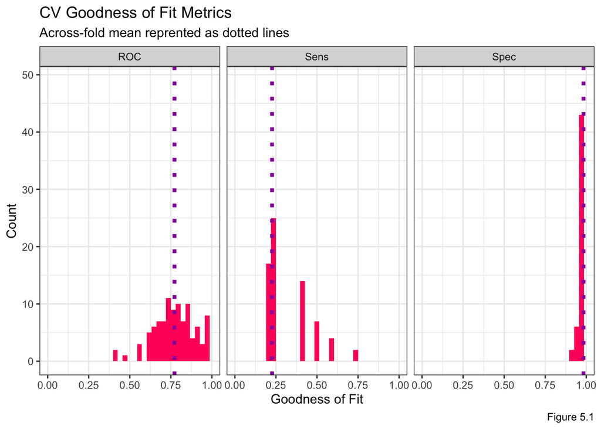

```r
dplyr::select(cvFit$resample, -Resample) %>%
  gather(metric, value) %>%
  left_join(gather(cvFit$results[2:4], metric, mean)) %>%
  ggplot(aes(value)) +
    geom_histogram(bins=35, fill = "#FF006A") +
    facet_wrap(~metric) +
    geom_vline(aes(xintercept = mean), colour = "#981FAC", linetype = 3, size = 1.5) +
    scale_x_continuous(limits = c(0, 1)) +
    labs(x="Goodness of Fit", y="Count", title="CV Goodness of Fit Metrics",
         subtitle = "Across-fold mean reprented as dotted lines",
         caption = "Figure 5.1") +
    theme_bw()
```

# 6: Cost-Benefit Calculation

An important part of this project is understanding how HCD can increase efficiency in its outreach and reducing costs. HCD recognizes that incorrectly predicting enrollment into the program will result in monetary loss for the agency.

Currently, HCD spends $2,850 per homeowner for this campaign. This is inclusive of associated employment, resource, and outreach costs. The credit allocated per enrolled homeowner in the home repair tax credit program is $5,000. Moreover, researchers evaluated that houses were renovated under this program typically sold with a $10,000 premium. Surrounding home would see an aggregate premium of $56,000 on average.

Given the new HCD targeting algorithm, I assume that 25 percent of the contacted eligible homeowners receive the credit. The remaining 75 percent that receive the marketing allocation and enter the program end up not taking the credit for various reasons. Working with these assumptions I create a cost-benefit calculation.

Here, I break down the costs associated to each type of prediction per homeowner:

- **True Positive**: would result in a net benefit of $58,150 for the *25 percent who receive the credit* and a net benefit of -$2,850 for the *75 percent who do not receive the credit*.
  - Cost: $2,850 from marketing and $5,000 for credit allocation
  - Benefit: $10,000 premium on home and $56,000 on surrounding home values
- **True Negative**: would result in $0 net benefit
  - Cost: no marketing expenditure
  - Benefit: none considered
- **False Positive**: would result in a net benefit of -$2,850
  - Cost: $2,850 spent on marketing
  - Benefit: none
- **False Negative**: would result in a $0 net benefit
  - Cost: none considered
  - Benefit: none

The table below displays the overall revenue of this campaign.

```r
cost_benefit_table <-
   testProbs %>%
      count(predOutcome, Outcome) %>%
      summarize(True_Negative = sum(n[predOutcome==0 & Outcome==0]),
                True_Positive = sum(n[predOutcome==1 & Outcome==1]),
                False_Negative = sum(n[predOutcome==0 & Outcome==1]),
                False_Positive = sum(n[predOutcome==1 & Outcome==0])) %>%
       gather(Variable, Count) %>%
       mutate(Revenue =
               case_when(Variable == "True_Negative" ~ Count * 0,
               Variable == "True_Positive" ~ ((58150) * (Count*0.25) + (-2850 * (Count*0.75))),
               Variable == "False_Negative" ~ Count*0,
               Variable == "False_Positive" ~ (-2850) * Count)) %>%
    bind_cols(data.frame(Description = c(
              "We correctly predicted no credit",
              "We correctly predicted might take credit",
              "We incorrectly predicted that they would not take the credit",
              "We incorrectly predicted that they would take the credit")))

kable(cost_benefit_table,
       caption = "Cost/Benefit Table") %>%
  kable_styling() %>%
  footnote(general_title = "\n", general = "Table 6.1")
```

Cost/Benefit Table

| Variable | Count | Revenue | Description |
| --- | --- | --- | --- |
| True_Negative | 1261 | 0 | We correctly predicted no credit |
| True_Positive | 37 | 458800 | We correctly predicted might take credit |
| False_Negative | 120 | 0 | We incorrectly predicted that they would not take the credit |
| False_Positive | 22 | -62700 | We incorrectly predicted that they would take the credit |

Table 6.1

## 6.1: Optimize Thresholds

Determining the optimal threshold for the model is essential in determining the performance of the model. As discussed in the previous sections, accuracy, sensitivity, and specificity are the most important indicators that I am using to decide to effectiveness of the model. When the threshold is altered in a model, it will impact the trade-off between sensitivity and specificity. This means that the model would be adjusting the trade-off between the true positive rate and the true negative rate.

When deciding on the optimal threshold for the model, it is important that the context of the project is considered. In this case, HCD would want to minimize true positive errors. HCD wants more eligible homeowners to enroll in the program.

```r
iterateThresholds <- function(data) {
  x = .01
  all_prediction <- data.frame()
  while (x <= 1) {

  this_prediction <-
      testProbs %>%
      mutate(predOutcome = ifelse(Probs > x, 1, 0)) %>%
      count(predOutcome, Outcome) %>%
      summarize(True_Negative = sum(n[predOutcome==0 & Outcome==0]),
                True_Positive = sum(n[predOutcome==1 & Outcome==1]),
                False_Negative = sum(n[predOutcome==0 & Outcome==1]),
                False_Positive = sum(n[predOutcome==1 & Outcome==0])) %>%
     gather(Variable, Count) %>%
     mutate(Revenue =
               case_when(Variable == "True_Negative" ~ Count * 0,
               Variable == "True_Positive" ~ ((58150) * (Count*0.25) + (-2850 * (Count*0.75))),
               Variable == "False_Negative" ~ Count*0,
               Variable == "False_Positive" ~ (-2850) * Count),
            Threshold = x)

  all_prediction <- rbind(all_prediction, this_prediction)
  x <- x + .01
  }
return(all_prediction)
}
```

### 6.1.1: Total Revenue by Threshold

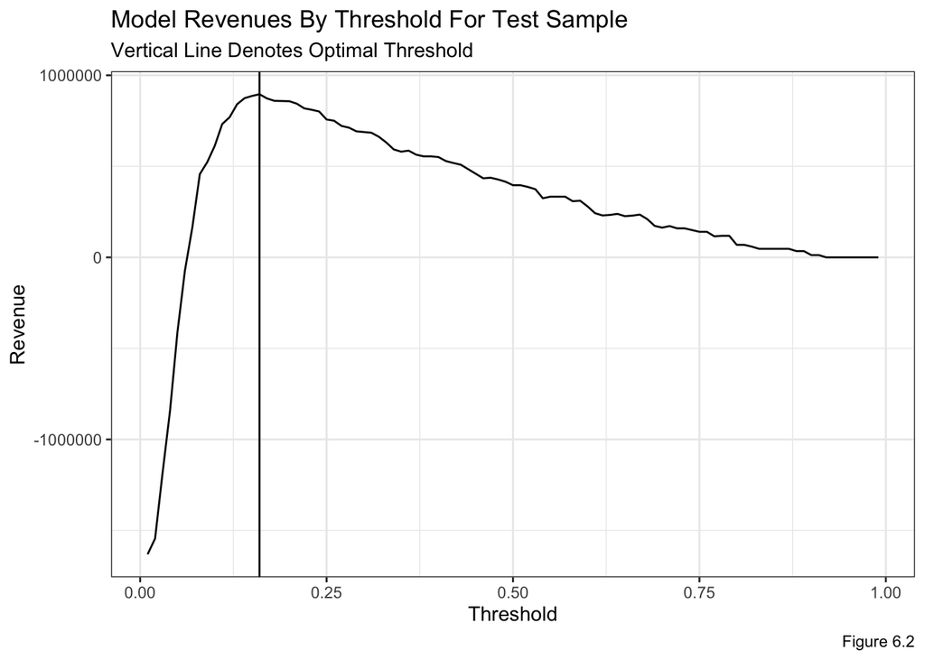

```r
whichThreshold <- iterateThresholds(testProbs2)

whichThreshold_revenue <-
whichThreshold %>%
    group_by(Threshold) %>%
    summarize(Revenue = sum(Revenue))

  ggplot(whichThreshold_revenue)+
  geom_line(aes(x = Threshold, y = Revenue))+
  geom_vline(xintercept =  pull(arrange(whichThreshold_revenue, -Revenue)[1,1]))+
    labs(title = "Model Revenues By Threshold For Test Sample",
         subtitle = "Vertical Line Denotes Optimal Threshold",
         caption = "Figure 6.2") +
    theme_bw()
```

### 6.1.2: Total Credits by Threshold

Figure 6.3 depicts the total amount of credits spent by HCD on this program based on the threshold set. This is considering that HCD will spent $5,000 in credit per homeowner that enrolls successfully in the program.

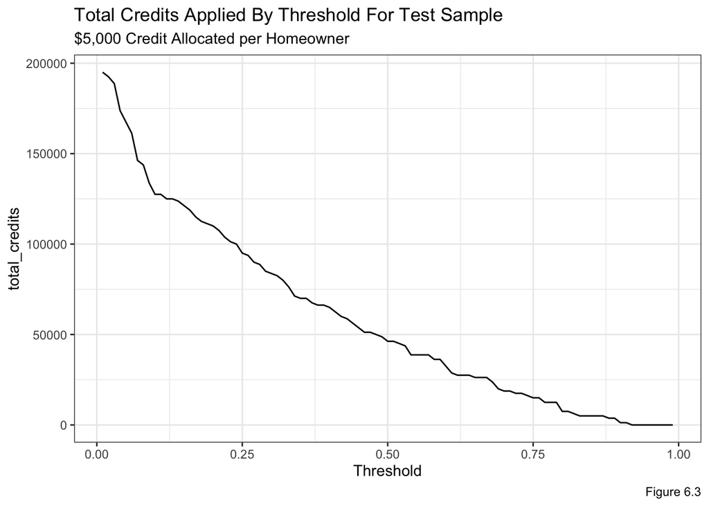

```r
whichThreshold_count <-
whichThreshold %>%
    group_by(Threshold) %>%
    filter(.,Variable == "True_Positive") %>%
    summarize(total_credits = (sum(Count))* 5000 * 0.25)

  ggplot(whichThreshold_count)+
  geom_line(aes(x = Threshold, y = total_credits))+
    labs(title = "Total Credits Applied By Threshold For Test Sample",
         subtitle = "$5,000 Credit Allocated per Homeowner",
         caption = "Figure 6.3") +
    theme_bw()
```

### 6.1.3: Confusion Matrix

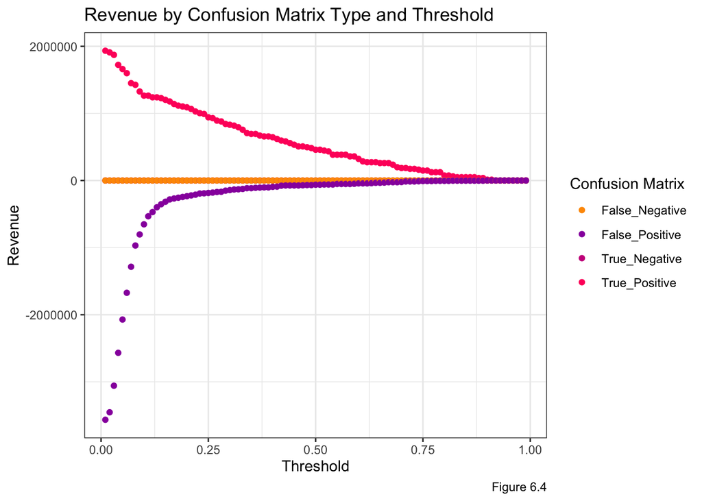

```r
whichThreshold %>%
  ggplot(.,aes(Threshold, Revenue, colour = Variable)) +
  geom_point() +
  scale_colour_manual(values = palette5[c(5, 1:3)]) +
  labs(title = "Revenue by Confusion Matrix Type and Threshold",
       y = "Revenue",
       caption = "Figure 6.4") +
  guides(colour=guide_legend(title = "Confusion Matrix"))+
  theme_bw()
```

### 6.1.4: Comparing Thresholds

```r
totalThreshold <- merge(x = whichThreshold_count, y = whichThreshold_revenue, by = "Threshold", all = TRUE)

comparingThresholds <- totalThreshold %>%
  filter((Threshold < 0.51 & Threshold > 0.491) |(Threshold < 0.139 & Threshold > 0.129))

kable(comparingThresholds,
      caption = "Comparing Thresholds") %>%
  kable_styling() %>%
  footnote(general_title = "\n",
           general = "Table 6.5")
```

Comparing Thresholds

| Threshold | total_credits | Revenue |
| --- | --- | --- |
| 0.13 | 125000 | 841000 |
| 0.50 | 46250 | 396100 |

Table 6.5

# 7: Conclusion

Currently, this model performs better than a coin flip. Therefore, we can assume that this model will be able to select potential homeowners who would enroll in the home repair tax credit program better than how HCD currently does its randomized selection. I believe that HCD could use this model for a preliminary trial to study the efficacy of the model. The main critique I have of the current model is that it is built using unbalanced data. The data collected by HCD heavily skews toward homeowners who do not enroll in the program. Currently such a few number of homeowners enroll that it is impossible to build a generalizable model.

I recommend that HCD starts testing this model in practice, while continuing to collect data on program enrollment. Over time, as HCD collects more data, it should be incorporated into the model so that the necessary adjustments can be made to create a more predictive, accurate, and generalizable model.

## 7.1: Acknowledgement

Sections of this code was done in collaboration with Xiaofan Liu.